# Regularization Models

Catalina Valencia

**Project:** US Crime Rate Modeling: Regression, Regularization, and Tree-Based Methods

**File:** 04_regularization_models.Rmd

### Objectives:

- Address multicollinearity and overfitting using regularization
- Fit and compare Stepwise, Ridge, Lasso, and Elastic Net models
- Examine coefficient shrinkage and variable selection behavior

### Notes:

- Stepwise regression serves as a classical baseline
- Penalized models require standardized predictors
- Emphasis is on stability and generalization, not inference

Environment Setup

```r
rm(list = ls())
set.seed(1)
```

Load Required Libraries

```r
library(glmnet)
```

Load Data

```r
crimedata <- read.table(
  "../data/uscrime.txt",
  header = TRUE
)
```

Response and Predictor Separation

```r
y <- crimedata$Crime
X <- crimedata[, -which(names(crimedata) == "Crime")]
```

### Full Linear Regression Model

Baseline multiple linear regression using all predictors

```r
full_lm <- lm(Crime ~ ., data = crimedata)
summary(full_lm)
```

```
##
## Call:
## lm(formula = Crime ~ ., data = crimedata)
##
## Residuals:
##     Min      1Q  Median      3Q     Max
## -395.74  -98.09   -6.69  112.99  512.67
##
## Coefficients:
##               Estimate Std. Error t value Pr(>|t|)
## (Intercept) -5.984e+03  1.628e+03  -3.675 0.000893 ***
## M            8.783e+01  4.171e+01   2.106 0.043443 *
## So          -3.803e+00  1.488e+02  -0.026 0.979765
## Ed           1.883e+02  6.209e+01   3.033 0.004861 **
## Po1          1.928e+02  1.061e+02   1.817 0.078892 .
## Po2         -1.094e+02  1.175e+02  -0.931 0.358830
## LF          -6.638e+02  1.470e+03  -0.452 0.654654
## M.F          1.741e+01  2.035e+01   0.855 0.398995
## Pop         -7.330e-01  1.290e+00  -0.568 0.573845
## NW           4.204e+00  6.481e+00   0.649 0.521279
## U1          -5.827e+03  4.210e+03  -1.384 0.176238
## U2           1.678e+02  8.234e+01   2.038 0.050161 .
## Wealth       9.617e-02  1.037e-01   0.928 0.360754
## Ineq         7.067e+01  2.272e+01   3.111 0.003983 **
## Prob        -4.855e+03  2.272e+03  -2.137 0.040627 *
## Time        -3.479e+00  7.165e+00  -0.486 0.630708
## ---
## Signif. codes:  0 '***' 0.001 '**' 0.01 '*' 0.05 '.' 0.1 ' ' 1
##
## Residual standard error: 209.1 on 31 degrees of freedom
## Multiple R-squared:  0.8031, Adjusted R-squared:  0.7078
## F-statistic: 8.429 on 15 and 31 DF,  p-value: 3.539e-07
```

**Results:**

The full linear regression model includes all p = 15 predictors and is fit on n = 47 observations.

- Multiple R-squared: 0.8031
- Adjusted R-squared: 0.7078
- Residual standard error: 209.1

The model shows strong in-sample fit, but the gap between multiple and adjusted R-squared indicates limited contribution from some predictors.

Large standard errors and weak individual significance suggest multicollinearity, supporting variable selection and regularization.

- Reduce model complexity using information criteria.
- Retain interpretability while mitigating overfitting.

**Notes:**

- Stepwise selection is heuristic and unstable under multicollinearity, motivating regularization methods.

```r
stepwise_model <- step(
  full_lm,
  direction = "both",
  trace = FALSE
)

summary(stepwise_model)
```

```
##
## Call:
## lm(formula = Crime ~ M + Ed + Po1 + M.F + U1 + U2 + Ineq + Prob,
##     data = crimedata)
##
## Residuals:
##     Min      1Q  Median      3Q     Max
## -444.70 -111.07    3.03  122.15  483.30
##
## Coefficients:
##             Estimate Std. Error t value Pr(>|t|)
## (Intercept) -6426.10    1194.61  -5.379 4.04e-06 ***
## M              93.32      33.50   2.786  0.00828 **
## Ed            180.12      52.75   3.414  0.00153 **
## Po1           102.65      15.52   6.613 8.26e-08 ***
## M.F            22.34      13.60   1.642  0.10874
## U1          -6086.63    3339.27  -1.823  0.07622 .
## U2            187.35      72.48   2.585  0.01371 *
## Ineq           61.33      13.96   4.394 8.63e-05 ***
## Prob        -3796.03    1490.65  -2.547  0.01505 *
## ---
## Signif. codes:  0 '***' 0.001 '**' 0.01 '*' 0.05 '.' 0.1 ' ' 1
##
## Residual standard error: 195.5 on 38 degrees of freedom
## Multiple R-squared:  0.7888, Adjusted R-squared:  0.7444
## F-statistic: 17.74 on 8 and 38 DF,  p-value: 1.159e-10
```

**Results:**

M, Ed, Po1, M.F, U1, U2, Ineq, Prob

Model fit:

- Multiple R-squared: 0.7888
- Adjusted R-squared: 0.7444
- Residual standard error: 195.5

Relative to the full model, stepwise selection reduces dimensionality while preserving similar explanatory power.

**Predictor Scaling for Regularization**

- Required for Ridge, Lasso, and Elastic Net.
- Ensures fair penalization across predictors.
- Response variable remains unscaled.

```r
X_scaled <- scale(X)

X_center <- attr(X_scaled, "scaled:center")
X_scale  <- attr(X_scaled, "scaled:scale")
```

**Results:**

Predictors were standardized for regularization; the response variable was not scaled.

### Ridge Regression (alpha = 0)

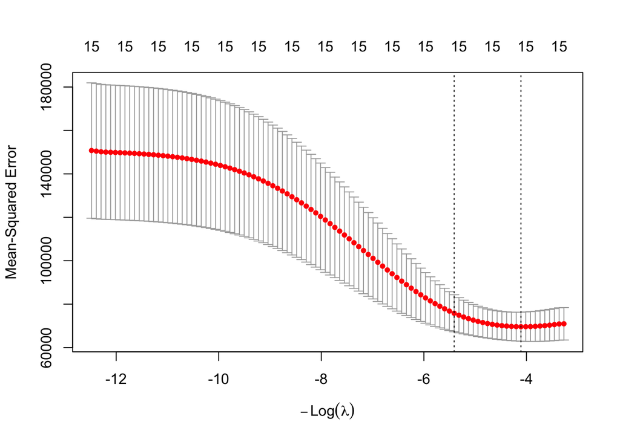

```r
ridge_cv <- cv.glmnet(
  x = X_scaled,
  y = y,
  alpha = 0
)

plot(ridge_cv)
```

```r
lambda_ridge <- ridge_cv$lambda.min
lambda_ridge
```

```
## [1] 60.77845
```

```r
ridge_model <- glmnet(
  x = X_scaled,
  y = y,
  alpha = 0,
  lambda = lambda_ridge
)

summary(ridge_model)
```

```
##           Length Class     Mode
## a0         1     -none-    numeric
## beta      15     dgCMatrix S4
## df         1     -none-    numeric
## dim        2     -none-    numeric
## lambda     1     -none-    numeric
## dev.ratio  1     -none-    numeric
## nulldev    1     -none-    numeric
## npasses    1     -none-    numeric
## jerr       1     -none-    numeric
## offset     1     -none-    logical
## call       5     -none-    call
## nobs       1     -none-    numeric
```

```r
ridge_cv$lambda.1se
```

```
## [1] 223.5662
```

**Results:**

Ridge regression was fit using 10-fold cross-validation.

- Optimal penalty parameter (lambda.min): 60.7785
- One-standard-error penalty (lambda.1se): 223.5662

Coefficient magnitudes are shrunk toward zero, reducing variance under multicollinearity while retaining all predictors.

**Ridge Coefficients (Original Scale)**

```r
beta_ridge_std <- as.vector(coef(ridge_model))[-1]
beta_ridge_orig <- beta_ridge_std / X_scale

intercept_ridge_orig <- coef(ridge_model)[1] -
  sum(beta_ridge_orig * X_center)

beta_ridge_orig
```

```
##             M            So            Ed           Po1           Po2
##    58.3345808    91.3323483    81.6429083    46.2400815    39.0756413
##            LF           M.F           Pop            NW            U1
##   608.4687153    23.6358174     0.1334213     3.4433159 -2301.8273454
##            U2        Wealth          Ineq          Prob          Time
##    88.6926496     0.0356133    30.0433559 -3654.5780929     0.8000199
```

```r
intercept_ridge_orig
```

```
## [1] -4908.765
```

**Results:**

All predictors remain in the ridge regression model, with coefficients shrunk relative to the full OLS estimates.

- Largest-magnitude coefficients correspond to: Prob: -3654.5781 U1: -2301.8273

These predictors dominate the linear signal after shrinkage, indicating strong associations with crime rate. Ridge stabilizes estimation under multicollinearity but does not induce sparsity, motivating comparison with Lasso.

### Lasso Regression (alpha = 1)

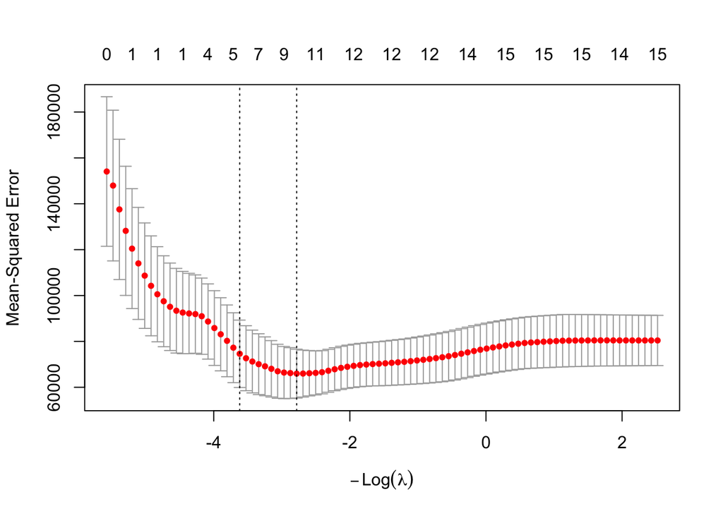

```r
lasso_cv <- cv.glmnet(
  x = X_scaled,
  y = y,
  alpha = 1
)

plot(lasso_cv)
```

```r
lambda_lasso <- lasso_cv$lambda.min
lambda_lasso
```

```
## [1] 16.14329
```

```r
lasso_model <- glmnet(
  x = X_scaled,
  y = y,
  alpha = 1,
  lambda = lambda_lasso
)

summary(lasso_model)
```

```
##           Length Class     Mode
## a0         1     -none-    numeric
## beta      15     dgCMatrix S4
## df         1     -none-    numeric
## dim        2     -none-    numeric
## lambda     1     -none-    numeric
## dev.ratio  1     -none-    numeric
## nulldev    1     -none-    numeric
## npasses    1     -none-    numeric
## jerr       1     -none-    numeric
## offset     1     -none-    logical
## call       5     -none-    call
## nobs       1     -none-    numeric
```

One-standard-error penalty:

```r
lambda_1se <- lasso_cv$lambda.1se
lambda_1se
```

```
## [1] 37.29309
```

Number of nonzero coefficients at lambda.min:

```r
num_nonzero <- sum(coef(lasso_model)[-1] != 0)
num_nonzero
```

```
## [1] 10
```

**Results:**

Lasso regression was fit using 10-fold cross-validation.

- Optimal penalty parameter (lambda.min): 16.1433
- One-standard-error penalty (lambda.1se): 37.2931

At lambda.min:

- Number of nonzero coefficients: 10

Lasso enforces sparsity by shrinking some coefficients exactly to zero, yielding a more interpretable model.

**Lasso Coefficients (Original Scale)**

```r
beta_lasso_std <- as.vector(coef(lasso_model))[-1]
beta_lasso_orig <- beta_lasso_std / X_scale

intercept_lasso_orig <- coef(lasso_model)[1] -
  sum(beta_lasso_orig * X_center)

beta_lasso_orig
```

```
##             M            So            Ed           Po1           Po2
##    58.8867834    37.2600213    79.8866685   104.0406029     0.0000000
##            LF           M.F           Pop            NW            U1
##    12.8626863    16.4730837     0.0000000     0.3097757     0.0000000
##            U2        Wealth          Ineq          Prob          Time
##    29.5141350     0.0000000    39.6446258 -3291.8191769     0.0000000
```

```r
intercept_lasso_orig
```

```
## [1] -3995.939
```

**Lasso Variable Selection**

```r
selected_vars_lasso <- names(beta_lasso_orig)[beta_lasso_orig != 0]
selected_vars_lasso
```

```
##  [1] "M"    "So"   "Ed"   "Po1"  "LF"   "M.F"  "NW"   "U2"   "Ineq" "Prob"
```

**Results:**

The Lasso-selected model retains 10 predictors: M, So, Ed, Po1, LF, M.F, NW, U2, Ineq, Prob

This yields a sparse, interpretable model, though coefficient estimates are biased due to shrinkage. Variable selection can be sensitive to correlated predictors.

### Elastic Net Regression (alpha = 0.5)

- Combine Ridge shrinkage with Lasso sparsity.
- Handle groups of correlated predictors more gracefully.

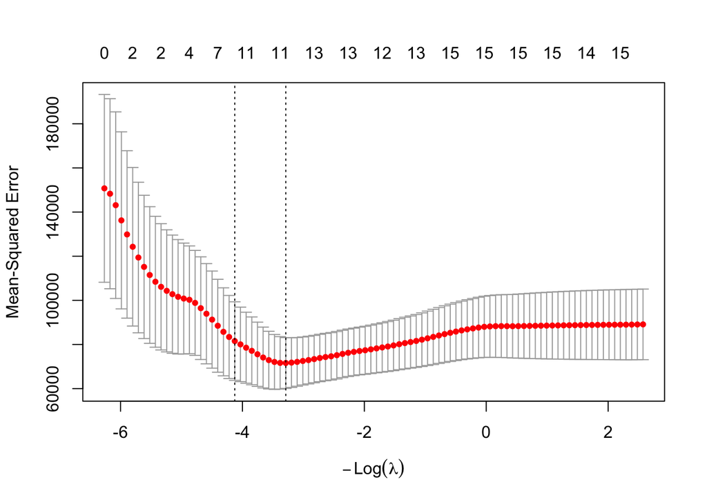

```r
alpha_enet <- 0.5

enet_cv <- cv.glmnet(
  x = X_scaled,
  y = y,
  alpha = alpha_enet
)

plot(enet_cv)
```

```r
lambda_enet <- enet_cv$lambda.min
lambda_enet
```

```
## [1] 26.80489
```

```r
enet_model <- glmnet(
  x = X_scaled,
  y = y,
  alpha = alpha_enet,
  lambda = lambda_enet
)

summary(enet_model)
```

```
##           Length Class     Mode
## a0         1     -none-    numeric
## beta      15     dgCMatrix S4
## df         1     -none-    numeric
## dim        2     -none-    numeric
## lambda     1     -none-    numeric
## dev.ratio  1     -none-    numeric
## nulldev    1     -none-    numeric
## npasses    1     -none-    numeric
## jerr       1     -none-    numeric
## offset     1     -none-    logical
## call       5     -none-    call
## nobs       1     -none-    numeric
```

**Results:**

This model balances shrinkage and sparsity, handling correlated predictors more gracefully than Lasso while maintaining interpretability.

Elastic Net Coefficients (Original Scale)

```r
beta_enet_std <- as.vector(coef(enet_model))[-1]
beta_enet_orig <- beta_enet_std / X_scale

intercept_enet_orig <- coef(enet_model)[1] -
  sum(beta_enet_orig * X_center)

beta_enet_orig
```

```
##            M           So           Ed          Po1          Po2           LF
##    56.733226    58.061303    74.697046    69.982670    29.961004   294.000709
##          M.F          Pop           NW           U1           U2       Wealth
##    17.775319     0.000000     1.256769  -364.327944    44.235963     0.000000
##         Ineq         Prob         Time
##    33.895193 -3493.176494     0.000000
```

```r
intercept_enet_orig
```

```
## [1] -4058.833
```

**Results:**

This model balances sparsity and shrinkage, offering a compromise between interpretability and stability.

### Conclusion

- Stepwise regression reduces predictors but is sensitive to correlated covariates.
- Ridge stabilizes all coefficients under multicollinearity but keeps all variables.
- Lasso selects a sparse set of predictors by shrinking some coefficients to zero.
- Elastic Net combines Lasso sparsity and Ridge stability, handling correlated predictors effectively.